# Final Project Prepartion - Stage 1

Spring 2022

### Final Project Stage 1: Asking a GIS question

#### Recorded Overview:

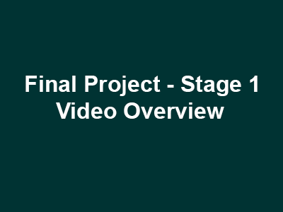

*Note: video requires a password for access as follows:* - **FPs1gis**

The final project is a core component of the course; it serves as a significant evaluation tool ensuring mastery of course material and technical aspects of the course. It also allows for exploration of course concepts and mastered skills for a specific research topic of your own choosing. As noted in the **Evaluations and Grading** section of the syllabus, the final project is worth 40% of the total grade - 10% is given to the stages leading up to the final presentation (starting now); and 30% is given to the presentation and final project organization and upload. The grading weights are excerpted from the syllabus as follows:

#### Evaluations and Grading:

| Course Component | Percentage |
| --- | --- |
| Weekly GIS technical assignments | 50% |
| Independent research, data development & project scope (Final Project) | 10% |
| Final GIS project presentation (Final Project) | 30% |
| Participation & weekly Quizzes | 10% |
| Total | 100% |

#### Three Stage Process:

The final project will be developed across 3 stages. The first stage - this assignment - is the asking of a GIS question. Once a GIS question is proposed and then refined, the second stage will leverage the refined GIS question into a full project proposal inclusive of data acquistion and selected spatial analysis methodology. The third stage will be the analysis itself and the development of project findings/outcomes, and reporting out those findings/outcomes in the form of a presentation and a short methods summary paper. For this first stage, there is no need to deliberate the second and third stages; rather, focus more narrowly on the GIS question itself. In response to the assignment deliverable, instructor will give feedback and suggest refinements and ‘next steps’ in preparation of the second stage.

#### What project themes are appropriate for this course ?

To develop a good GIS question for this course, it should first be consistent with the general themes and context of this course. As stated in the syllabus:

> students will segue towards developing their own GIS project for a particular research topic in international development, humanitarian relief or environmental studies.

Particular themes include:

- Social and physical vulnerability-exposures
- Demographic trend analysis
- Crisis & participatory mapping
- Climate change
- Humanitarian relief
- International development
- Urban analysis & design
- Resource management
- Land use issues
- Environmental risk analysis

#### Developing an effective GIS question:

Once a theme is ascertained, developing an effective question within the theme is still challenging, but generally falls within several typical categories. First, let’s establish 2 questions that are typically **not** effective GIS questions, and one type of question that comes with a warning:

- **Explanatory questions**: these type of questions usually start with ‘why’; several examples to follow:
  - why are certain entities located where they are ?
  - why are certain attributes part of the dataset ?
  - why have certain phenomena or entities changed in some way over time ?
- **Nonspatial questions**: these type of questions, while valuable, simply lack a spatial dimension or unit of analysis that would be meaningful and robust enough for a full GIS project. To avoid this problem, ask of the question itself the following:
  - is there a specific geography (global, regional or local) inherent to the question ?
  - do variables and data inputs for the project possess a spatial dimension; and do they have a unit of analysis be it points, lines or polygons in the vector model, or an appropriate resolution in the raster model ?
- **Predictive questions (warning)**: these type of questions fall into the ‘what if’ category. While there are GIS models and methodologies that can handle future scenarios - examples include land use and various urban planning processes - be careful that the ‘what if’ is the result and output of the analysis, not uncontrollable, hard-to-define variables outside the framework of the project.

Given these constraints and warning, let’s turn to typically **effective** GIS questions. These questions leverage the capacity of GIS to deliver answers that are not available through other analysis methods; or at least more meaningful answers than those derived by other methods:

- **Location - What is at ?** What is at a given location or where is a specific item located? A simple example:

> Where are oak trees located within certain North American geographies?

While this type of question seems obvious - and it is - importantly it defines the subject - oak trees - and a defined study area. Those two components can lead to a robust GIS analyis with further refinement.

- **Condition Where is it … ?** This question is the converse of the first type of question. Instead of identifying what exists at a given location, the goal is to find location(s) where certain conditions are satisfied. Example as follows:

> given terrain criteria, population requirements and access to transporation networks, what would be suitable locations for IDP camps in a certain region?
- **Trends - What has changed since … ?** This type of question has two dimensions - temporal and location. These are often very effective GIS questions. Simple example as follows:

> How has the forest cover changed since 1990 in Alaska?
- **Patterns - What spatial patterns exist in a certain geographies ?** In this type of question, relationships between variables with spatial dimensions are analyzed. A simple example as follows:

> How many people live within certain high risk zones prone to coastal flooding?
- **Networks – How to get to … ?** This type of question queries natural terrain or transporation networks to deliver insight into how humans, animals and materials move within geographies. This type of analysis can be quite complex and engaging beyond a very simple, limited example as follows:

> What is the fastest way from Boston to New York by car?
- **Modeling - How would it happen?**. This question often involves spatial data inputs to model a natural or manmade phenomena as it develops across a defined geography. While similar to trends and pattern questions, Modeling questions often offer multiple scenarios given the manipulation of input criteria and thresholds. Simple examples as follows:

> How would a forest fire spread within a certain county in Maine? What coastal geographies in Maine are most at risk of sea level rise?
- **Decisions - What should be done if… ?** In this type of question, a geographically defined risk or opportunity is analyzed for populations, vulnerabily populations, the built environment, protected land use areas, animal species and/ or the physical environment. A simple example as follows:

> In the event of a certain industrial accident, which local populations would be at high risk of exposure?

#### Stage 1 deliverable format:

Use the aforementioned prompts to develop a clearly defined spatial question. Additionally, develop a short narrative context for the question. Several prompts as follows:

- Why is theme context of the question important or compelling? How is the GIS question related to its larger theme?
- Is this spatial question part of a larger research agenda; if so, what findings might aid your work in answering the spatial question?
- What organizations, populations or geographies are particularly pertinent to your GIS question, and for what reason(s)?
- Does this GIS question stem from your personal or work experience; if so, are there non-spatial issues or general context that is important to understanding the GIS question itself?

The format of this Stage 1 deliverable should be a 3/4 to 1 page PDF narrative response uploaded to the CANVAS assignment section for this assignment.